# Exploratory Data Analysis

Group BB4 - Jeffrey Lan, Minh Trung Le, Wencheng Zhang, Yiding Zhang

05/20/2022

## Introduction

The wildfires incidents are increasing recently. This project can help paint the picture of the state of the earth and how it is important to protect the forest and our environment.

The data is used in this project collected is SQL lite file from: https://www.kaggle.com/datasets/rtatman/188-million-us-wildfires

### **Important**:

Please download the **SQL data set (FPA_FOD_20170508.sqlite)** from the link above and put it into **data folder** before executing the codes for this project.

This data publication contains a spatial database of wildfires that occurred in the United States from 1992 to 2015. This dataset was originally generated to support the national Fire Program Analysis (FPA) system. The wildfire records are acquired from the reporting systems of federal, state, and local fire organizations.

## Summary Information

The data reveals that the state had the most wildfire cases during 1992-2015 was **CA** with **189550** wildfires.

The state had the least wildfire cases during 1992-2015 was **DC** with **66** wildfires.

The biggest wildfire size was **INOWAK**, and it happened at **AK**, in **1997** with the size **6.06945^{5}** arces, and it was classified as class **G**.

There are 7 wildfire size classes. A is the smallest size and G is the biggest size.

The most wildfire size class happened during 1992-2015 was **B**, and it happened **939376** times.

The least wildfire size class happened during 1992-2015 was **G**, and it happened **3773** times.

## Table

### Fire count by states during 1992-2015

| STATE | NUMBER OF FIRES |
| --- | --- |
| CA | 189550 |
| GA | 168867 |
| TX | 142021 |
| NC | 111277 |
| FL | 90261 |
| SC | 81315 |
| NY | 80870 |
| MS | 79230 |
| AZ | 71586 |
| AL | 66570 |
| OR | 61088 |
| MN | 44769 |
| OK | 43239 |
| MT | 40767 |
| NM | 37478 |
| ID | 36698 |
| CO | 34157 |
| WA | 33513 |
| WI | 31861 |
| AR | 31663 |
| TN | 31154 |
| SD | 30963 |
| UT | 30725 |
| LA | 30013 |
| KY | 27089 |
| NJ | 25949 |
| PR | 22081 |
| WV | 21967 |
| VA | 21833 |
| MO | 17953 |
| NV | 16956 |
| ND | 15201 |
| WY | 14166 |
| ME | 13150 |
| AK | 12843 |
| MI | 10502 |
| HI | 9895 |
| PA | 8712 |
| NE | 7973 |
| KS | 7673 |
| CT | 4976 |
| IA | 4134 |
| MD | 3622 |
| OH | 3479 |
| MA | 2626 |
| NH | 2452 |
| IL | 2327 |
| IN | 2098 |
| RI | 480 |
| VT | 456 |
| DE | 171 |
| DC | 66 |

### Fire count by year during 1992-2015

| YEAR | NUMBER OF FIRES |
| --- | --- |
| 1992 | 67975 |
| 1993 | 61989 |
| 1994 | 75955 |
| 1995 | 71472 |
| 1996 | 75574 |
| 1997 | 61450 |
| 1998 | 68370 |
| 1999 | 89363 |
| 2000 | 96416 |
| 2001 | 86587 |
| 2002 | 75656 |
| 2003 | 68261 |
| 2004 | 69279 |
| 2005 | 88604 |
| 2006 | 114004 |
| 2007 | 95573 |
| 2008 | 85378 |
| 2009 | 78325 |
| 2010 | 79889 |
| 2011 | 90552 |
| 2012 | 72769 |
| 2013 | 64780 |
| 2014 | 67753 |
| 2015 | 74491 |

## Charts

### 1 - Map chart for distribution of wildfires across the US in 2015

This map chart shows the distribution of wildfires across the US in 2015.

From this chart, we can see the number of wildfires are very high in California and Texas.

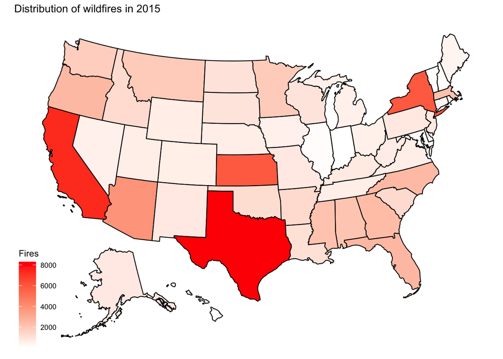

The following chart shows the progression of the top-5 states with most fire total counts during 1992-2015.

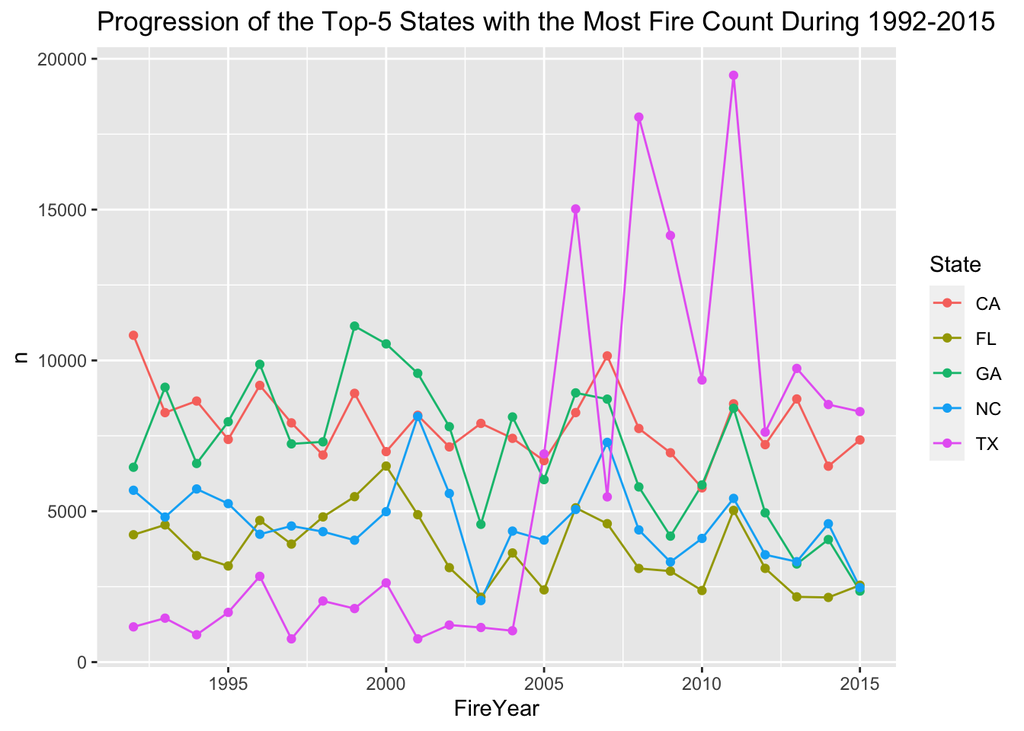

### 2 - Horizontal barplot for wildfires size classes during 1992-2015

This Horizontal barplot shows the relationship among wildfire size classes based on the number of fires happened during 1992-2015. There are 7 wildfire size classes from A to G, with A is the smallest size class and G is the biggest size class.

From this barplot, B size class was the most wildfires while the G size class had the least number of wildfires.

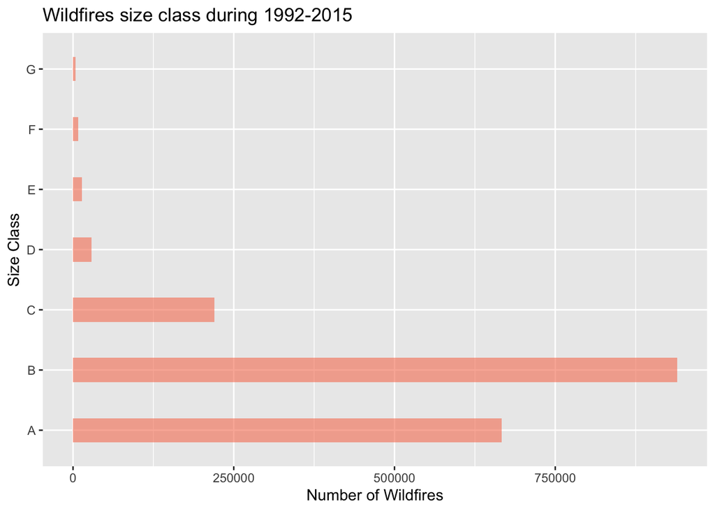

### 3 - Causes of Wildfires

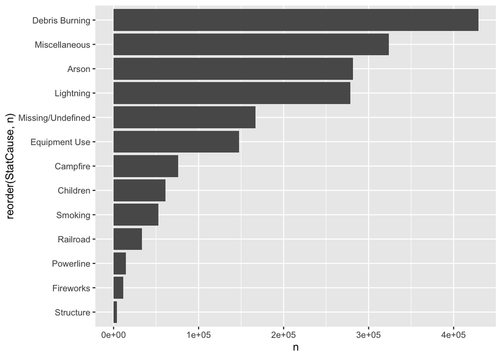

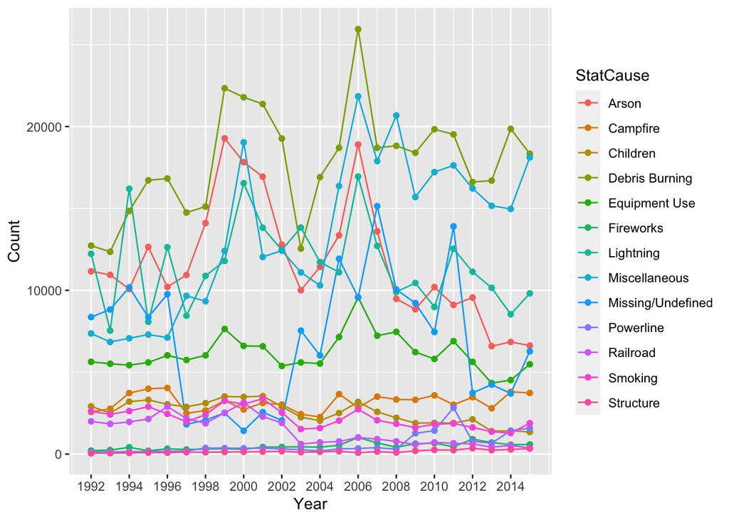

```r
plot(cause_progression)
```

### 4 - Bar plot

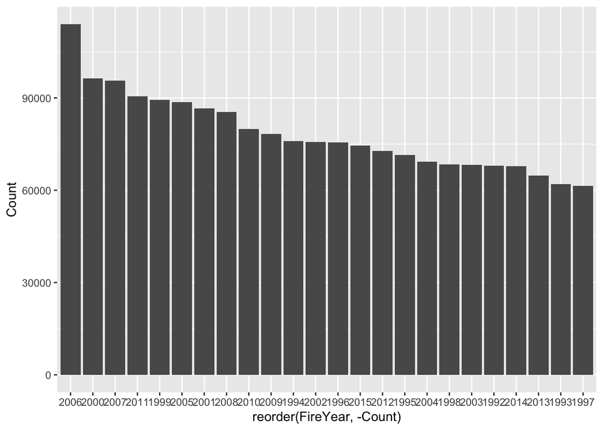